# ptt gossip 噓數預測神器

Lawrence Siao

April 5, 2017

## Outline

- Problem Statement
- Web Spider
- ETL
- Topic Model
- CNN model
- ToDo

## Problem Statement

擷取八卦版，標題為[新聞] 的文章，並預測其被噓次數。

## Web Spider

使用Scrapy，抓取八卦版全部文章 (使用四台t2-micro機器抓了快兩天)  
在將其轉為分辨pandas分析的csv檔  
**code:**  
**(src/json_to_csv.py)**

## ETL

filtered 掉標題為[新聞] 且 不是Re: 或Fw:的文章後

- 首先觀察其推文數統計值:

```
##    Min. 1st Qu.  Median    Mean 3rd Qu.    Max.
##    0.00    6.00   11.00   24.46   22.00 1448.00
```

- 箭頭數統計值:

```
##    Min. 1st Qu.  Median    Mean 3rd Qu.    Max.
##    0.00    5.00    9.00   15.52   17.00  779.00
```

- 噓文數統計值:

```
##    Min. 1st Qu.  Median    Mean 3rd Qu.    Max.
##   0.000   1.000   4.000   8.957  10.000 664.000
```

- 平均每篇文章噓數，以發文時間(小時)分群

| hour | mean | sd |
| --- | --- | --- |
| 0 | 6.824067 | 11.986220 |
| 1 | 6.486922 | 10.295450 |
| 2 | 6.694064 | 10.069598 |
| 3 | 5.295082 | 7.068366 |
| 4 | 17.377622 | 29.509322 |
| 5 | 12.789916 | 21.236311 |
| 6 | 16.012195 | 21.810411 |
| 7 | 17.034483 | 33.444672 |
| 8 | 13.624161 | 22.076517 |
| 9 | 11.479702 | 19.330658 |
| 10 | 10.865744 | 24.911116 |
| 11 | 10.538601 | 17.843517 |
| 12 | 10.198352 | 19.370149 |
| 13 | 9.771393 | 18.166217 |
| 14 | 8.924879 | 14.384446 |
| 15 | 10.076040 | 19.304600 |
| 16 | 9.876381 | 17.921831 |
| 17 | 9.897344 | 17.114941 |
| 18 | 8.109312 | 13.253369 |
| 19 | 7.412404 | 13.294850 |
| 20 | 7.313763 | 14.045883 |
| 21 | 6.050029 | 11.903141 |
| 22 | 5.381277 | 10.441926 |
| 23 | 4.932646 | 10.367841 |

可看出似乎有幾個斷點存在 1. 18-03點 2.04-08點 3. 09-17點  
其中於04-08點發的文章噓數通常較高，  
接下來是09-17點發的，  
最低的通常是18-03點發的文章  
因此我們可以根據其發文時間點給定新的Tag，依序為**WakeUp,Work,OutOfWork**

- 噓文數以發文時間(weekday)分群

| weekday | mean | sd |
| --- | --- | --- |
| Friday | 8.745351 | 16.40239 |
| Monday | 8.926459 | 16.25227 |
| Saturday | 9.001198 | 19.98266 |
| Sunday | 9.136213 | 16.99936 |
| Thursday | 8.824428 | 15.36039 |
| Tuesday | 8.929967 | 16.88166 |
| Wednesday | 9.184783 | 18.71305 |

可以看出似乎禮拜日和禮拜三噓文數較高，而禮拜五噓文數較低，但差距不大。  
因此使用T-test來檢定這兩個群體是不是來自不同母體

```
## [1] 0.2616253
```

- weekday v.s hour  
  接下來看weekay vs hour的heatmap, 越紅代表該時段發文的噓文數越低，越黃代表越高

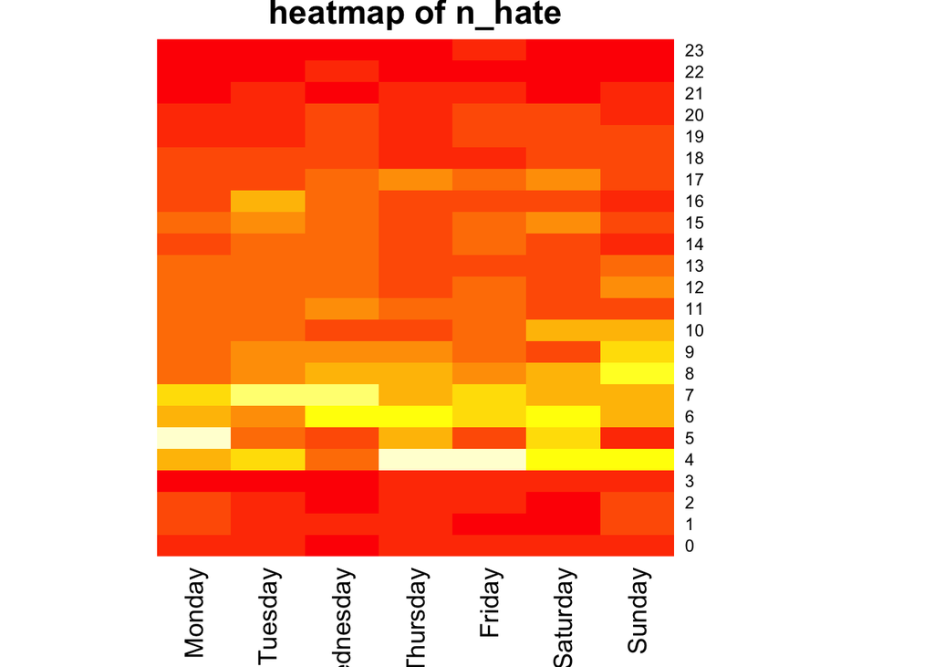

  沒有特別的趨勢Q_Q

## Topic Model

以ptt文章來講，要判斷該文的回覆率和噓文數，該文章的內容是不是符合最近的’風向’是 很重要的，因此為了找出能代表’風向’的feature，這裡使用LDA based (Latent Dirichlet allocation) 的topic model，來提文章分主題。  
簡單的來說，Topic Model選定好k個主題後，  
會output各個主題是由各哪些關鍵詞組成的  
ex: topic1 : 政府、勞動部、一例一休 topic2：小模、土豪、命案、W飯店  
以及各個文章文章是由哪些哪些主題組成：  
ex: document1: [(0.2, topic1), (0.6, topic3),(0.2, topic5)]  
步驟如下:  
1.因為是中文文章，因此必須先用jieba斷詞  
2.再把斷詞後的結果為每個文章內的每個詞算出其tf-idf值  
3.選定tf-idf 0.1，tf-idf >0.1的詞彙留下當作該文章的關鍵詞  
4.選定前兩週的文章內容去train Topic  
Model，然後根據每篇文章的噓文數、推文數、和箭頭數來計算每個主題的噓文指數、推文指數、和箭頭指數。  
ex: document1 被分類為[(0.2, topic1), (0.6, topic3),(0.2, topic5)]，而其獲得20噓，30推，40箭頭。  
document2 被分類為[(0.3, topic1), (0.5, topic3),(0.2, topic5)]，而其獲得40噓，50推，60箭頭。  
因此在document1上，topic1獲得(0.2*20+0.3*40)/(0.2+0.3)分的的噓文指數  
接下來用該model去判斷接下來六小時文章的主題，根據過去兩週train好的model裡各主題的噓、推、箭頭指數，去判斷該文章的噓、推、箭頭指數。  
ex:documet1 為 [(0.2, topic1), (0.6, topic3),(0.2, topic5)]，而topic1的噓文指數為23,topic3的噓文指數為26,topic5的噓文指數為33。  
因此documet1的噓文指數為0.2*23 + 0.6*26 + 0.2*33  
最後將全部的時間切成每六小時一個區段，每六小時跑一次往前兩週的model來判斷未來的六小時文章的噓、推、箭頭指數，再將這三個指數當做文章的三個features

**code:**  
**src/tfidf.py**  
**src/topic_model_features_generator.py**

## CNN model

除此之外利用word embedding、n-gram、結合而成的CNN model (convolution neural network)，可以有效擷取文章的前後句的資訊。這個model已經證實在判斷文章的總類上 有很好的效果(http://www.wildml.com/2015/12/implementing-a-cnn-for-text-classification-in-tensorflow/)，而這裡我們要做的事將這個model的response改成regression，並用RMSE當做cost function，以及要在最後的fully-connected層之前加上我們前面求得的meta features(前面算的hour_tag和文章的噓文指數、推文指數、箭頭指數等四個)。

## Results

比較模型的效果  
baseline1: 以全部文章平均噓數來做預測的話RMSE為17.20793  
baseline2: 以前一天的文章平均噓數來做預測的話RMSE為17.24406  
basic CNN: 純粹 CNN model未加入任何meta feature，RMSE為15.1172  
CNN with 3 meta-features: 純粹 CNN text model加入噓文指數、推文指數、箭頭指數，RMSE為13.8578  
CNN with 4 meta-features: 純粹 CNN text model加入噓文指數、推文指數、箭頭指數以及hour-tag，RMSE為13.7701

## ToDo

1. 在jieba的斷詞上還是有很多詞沒有斷的很好，所能用人工的方式加入一些domain knowledge去加入詞彙，或者用transfer learning的方式找一些別人段好的詞庫，效果將會更好。
2. 目險選用的topic model(LDA )目前使用的是bag of words的方式，這個方式的缺點是沒有辦法考慮前後文的關係，之前文章還有看到現在比較進階的是結合words-embedding的方式來分主題，可以更考慮到詞彙間的關係，不過這次project為了快點有個雛形出來，就先選用這個比較多人做過的方式。
3. 在cnn model的optimizer目前是是用Adam algorithm，而我們這個主題來講，training data 的參考性應該是文章發布時間點越接近現在的資料，參考性越高，這種型態的資料，之前有看過別人KDD Cup冠軍的做法，是用一種叫time-deterministic gradient descent的方式，會將越近期的data放到越後面的step來train，因此整個model就會越偏向將近期的資料預測準。
4. 在作者的資訊上，目前還沒有著墨到，這也是很好的方向可以去找出更多的feature，比如說找出某些作者是比較頃向發噓文的，或者用look alike的方式找出某些行為跟那些發噓文的人很類似的，來判斷他可能也是一個未來會發噓文的作者，應該是可以讓model更精準一點。
5. 目前使用到的資料都只有那些標題為[新聞]的文章，其他文章其實應該也有很大的參考價值。比如說某些主題的發酵，都是從某個爆文的[爆卦]文開始，因此要是把這個部分的資訊也加入model，應該也可以提升一些精準度。

** code:https://github.com/lawrencesiao/ptt_gossip **